# Assignment 10A: Sentiment Analysis

- Show All Code
- Hide All Code

DATA 607 · Code Base

Author

Dillon Leeper

Published

November 8, 2026

## Overview

| **Part 1** | Reproduces Chapter 2 of *Text Mining with R* (Silge and Robinson): sentiment analysis of Jane Austen’s novels, using the book’s code unchanged |
| --- | --- |
| **Part 2** | Runs the same tests on *The Great Gatsby* (1925) and *The Sun Also Rises* (1926), adds a fourth method (`sentimentr`), and scores the scenes around each main character |
| **Question** | Does the Chapter 2 approach tell the same story on two 1920s novels as it does on Austen? |

Source: Silge, J., & Robinson, D. (2017). *Text Mining with R: A Tidy Approach*, Chapter 2, “Sentiment analysis with tidy data.” https://www.tidytextmining.com/sentiment.html. Original code: https://github.com/dgrtwo/tidy-text-mining.

## Key findings

- **Tone:** *Gatsby* is the only one of the eight books that scores negative overall. *The Sun Also Rises* is positive, but less so than any Austen novel.
- **Misread words:** every book has one. “miss” (a title) for Austen and *Gatsby*, “damned” (used to mean “very”) for *The Sun Also Rises*.
- **Darkest chapter:** found correctly for *Gatsby* (the Plaza fight and Myrtle’s death), wrong for *The Sun Also Rises* (a fishing trip, flagged because of a joke).
- **Sentence-level scoring:** `sentimentr` fixes some negations (“not too pleasant”) and breaks others (“Don’t be a damned fool”).
- **Characters:** in *Gatsby*, the scenes around Tom, Jordan, Myrtle and George Wilson lean negative. In *The Sun Also Rises*, everyone stays near neutral.

Details and numbers are in How the Results Differ from the Original.

## Setup

```r
library(tidytext)
library(janeaustenr)
library(dplyr)
library(stringr)
library(tidyr)
library(ggplot2)
library(wordcloud)
library(reshape2)
library(gutenbergr)
library(readr)
library(sentimentr)
library(knitr)
```

**NoteBefore rendering**

The AFINN and NRC lexicons download through the `textdata` package, which asks you to accept each license the first time. That prompt can’t be answered during a render, so run `get_sentiments("afinn")` and `get_sentiments("nrc")` once in the R console first. After that they load from the local cache.

# Part 1: Reproducing Chapter 2

## 2.1 The sentiment lexicons

Three general-purpose lexicons, each scoring single words:

| Lexicon | How it scores a word |
| --- | --- |
| AFINN | A number from -5 (very negative) to +5 (very positive) |
| Bing | Positive or negative |
| NRC | Positive or negative, plus eight emotions (anger, anticipation, disgust, fear, joy, sadness, surprise, trust) |

```r
get_sentiments("afinn")
```

```
# A tibble: 2,477 × 2
   word       value
   <chr>      <dbl>
 1 abandon       -2
 2 abandoned     -2
 3 abandons      -2
 4 abducted      -2
 5 abduction     -2
 6 abductions    -2
 7 abhor         -3
 8 abhorred      -3
 9 abhorrent     -3
10 abhors        -3
# ℹ 2,467 more rows
```

```r
get_sentiments("bing")
```

```
# A tibble: 6,786 × 2
   word        sentiment
   <chr>       <chr>
 1 2-faces     negative
 2 abnormal    negative
 3 abolish     negative
 4 abominable  negative
 5 abominably  negative
 6 abominate   negative
 7 abomination negative
 8 abort       negative
 9 aborted     negative
10 aborts      negative
# ℹ 6,776 more rows
```

```r
get_sentiments("nrc")
```

```
# A tibble: 13,872 × 2
   word        sentiment
   <chr>       <chr>
 1 abacus      trust
 2 abandon     fear
 3 abandon     negative
 4 abandon     sadness
 5 abandoned   anger
 6 abandoned   fear
 7 abandoned   negative
 8 abandoned   sadness
 9 abandonment anger
10 abandonment fear
# ℹ 13,862 more rows
```

## 2.2 Sentiment analysis with inner join

Turn the Austen novels into one word per row, keeping track of the line and chapter each word came from.

```r
tidy_books <- austen_books() %>%
  group_by(book) %>%
  mutate(
    linenumber = row_number(),
    chapter = cumsum(str_detect(text,
                                regex("^chapter [\\divxlc]",
                                      ignore_case = TRUE)))) %>%
  ungroup() %>%
  unnest_tokens(word, text)
```

The most common “joy” words in *Emma*:

```r
nrc_joy <- get_sentiments("nrc") %>%
  filter(sentiment == "joy")

tidy_books %>%
  filter(book == "Emma") %>%
  inner_join(nrc_joy) %>%
  count(word, sort = TRUE)
```

```
# A tibble: 301 × 2
   word          n
   <chr>     <int>
 1 good        359
 2 friend      166
 3 hope        143
 4 happy       125
 5 love        117
 6 deal         92
 7 found        92
 8 present      89
 9 kind         82
10 happiness    76
# ℹ 291 more rows
```

Net sentiment (positive words minus negative words) in each 80-line section of each novel, using Bing:

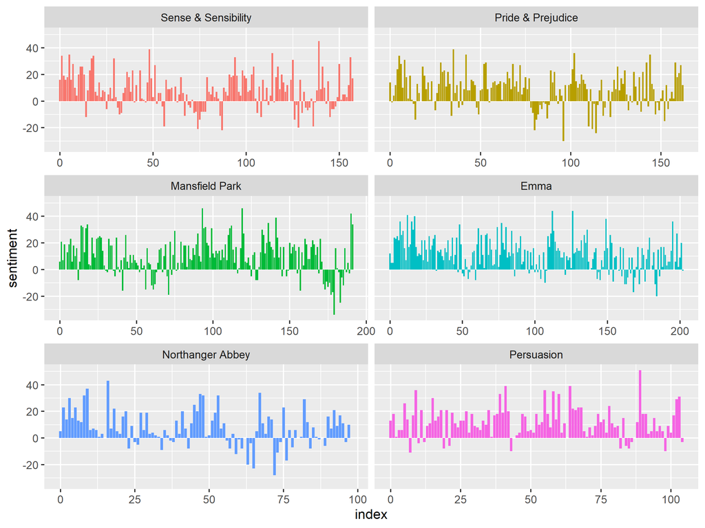

```r
jane_austen_sentiment <- tidy_books %>%
  inner_join(get_sentiments("bing")) %>%
  count(book, index = linenumber %/% 80, sentiment) %>%
  pivot_wider(names_from = sentiment, values_from = n, values_fill = 0) %>%
  mutate(sentiment = positive - negative)

ggplot(jane_austen_sentiment, aes(index, sentiment, fill = book)) +
  geom_col(show.legend = FALSE) +
  facet_wrap(~book, ncol = 2, scales = "free_x")
```

## 2.3 Comparing the three lexicons

All three lexicons on *Pride & Prejudice*:

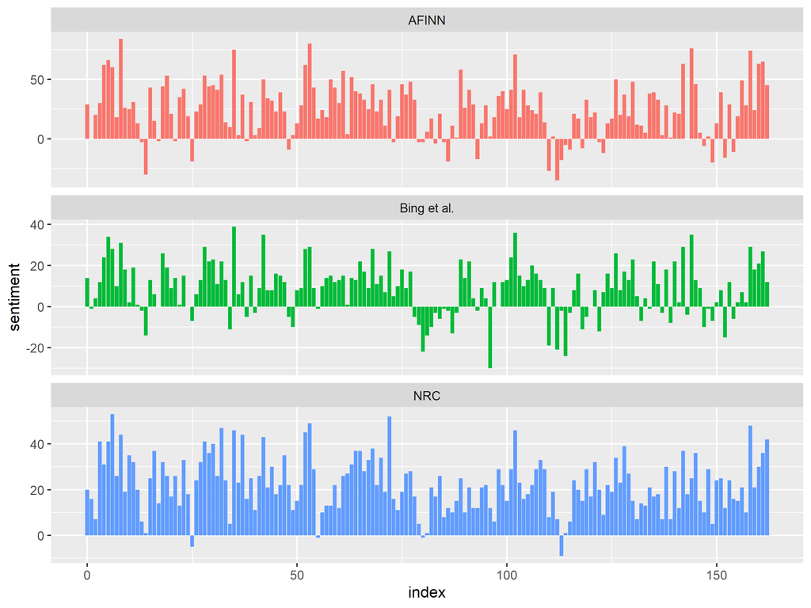

```r
pride_prejudice <- tidy_books %>%
  filter(book == "Pride & Prejudice")

afinn <- pride_prejudice %>%
  inner_join(get_sentiments("afinn")) %>%
  group_by(index = linenumber %/% 80) %>%
  summarise(sentiment = sum(value)) %>%
  mutate(method = "AFINN")

bing_and_nrc <- bind_rows(
  pride_prejudice %>%
    inner_join(get_sentiments("bing")) %>%
    mutate(method = "Bing et al."),
  pride_prejudice %>%
    inner_join(get_sentiments("nrc") %>%
                 filter(sentiment %in% c("positive",
                                         "negative"))
    ) %>%
    mutate(method = "NRC")) %>%
  count(method, index = linenumber %/% 80, sentiment) %>%
  pivot_wider(names_from = sentiment,
              values_from = n,
              values_fill = 0) %>%
  mutate(sentiment = positive - negative)

bind_rows(afinn,
          bing_and_nrc) %>%
  ggplot(aes(index, sentiment, fill = method)) +
  geom_col(show.legend = FALSE) +
  facet_wrap(~method, ncol = 1, scales = "free_y")
```

The book’s explanation for why NRC runs higher than Bing: the two lexicons have different ratios of negative to positive words.

```r
get_sentiments("nrc") %>%
  filter(sentiment %in% c("positive", "negative")) %>%
  count(sentiment)
```

| sentiment | n |
| --- | --- |
| negative | 3316 |
| positive | 2308 |

```r
get_sentiments("bing") %>%
  count(sentiment)
```

| sentiment | n |
| --- | --- |
| negative | 4781 |
| positive | 2005 |

## 2.4 Most common positive and negative words

```r
bing_word_counts <- tidy_books %>%
  inner_join(get_sentiments("bing")) %>%
  count(word, sentiment, sort = TRUE) %>%
  ungroup()

bing_word_counts
```

```
# A tibble: 2,585 × 3
   word     sentiment     n
   <chr>    <chr>     <int>
 1 miss     negative   1855
 2 well     positive   1523
 3 good     positive   1380
 4 great    positive    981
 5 like     positive    725
 6 better   positive    639
 7 enough   positive    613
 8 happy    positive    534
 9 love     positive    495
10 pleasure positive    462
# ℹ 2,575 more rows
```

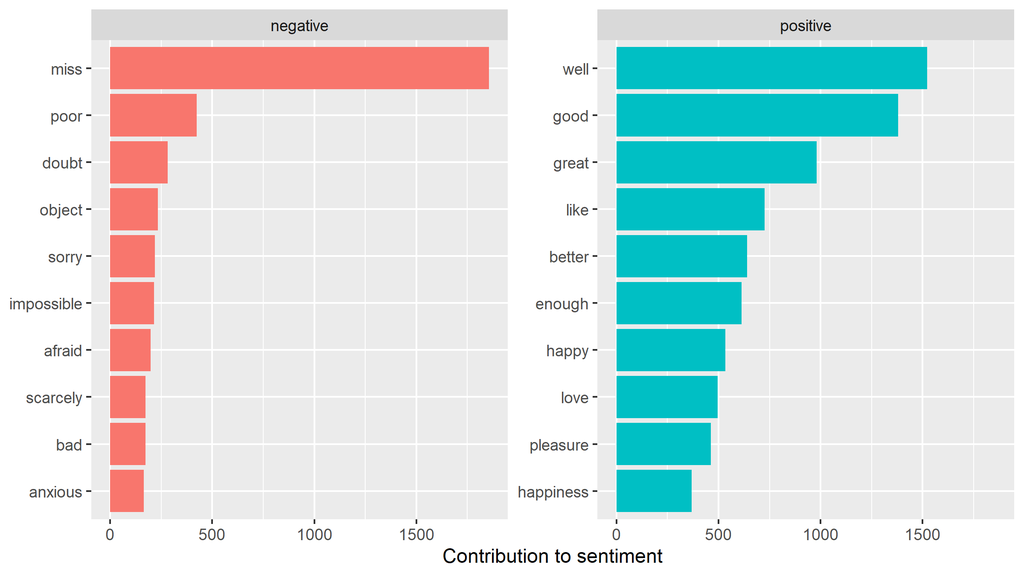

```r
bing_word_counts %>%
  group_by(sentiment) %>%
  slice_max(n, n = 10) %>%
  ungroup() %>%
  mutate(word = reorder(word, n)) %>%
  ggplot(aes(n, word, fill = sentiment)) +
  geom_col(show.legend = FALSE) +
  facet_wrap(~sentiment, scales = "free_y") +
  labs(x = "Contribution to sentiment",
       y = NULL)
```

“miss” is scored negative, but Austen uses it as a title (“Miss Bennet”). The book’s fix is a custom stop word. Stop words are common words like “the” and “and” that get removed before counting, using `anti_join()`. Adding “miss” to that list means it gets removed too, so it can’t count as negative. The book builds the list here but doesn’t rerun anything with it. Part 2 applies it to *Gatsby*.

```r
custom_stop_words <- bind_rows(tibble(word = c("miss"),
                                      lexicon = c("custom")),
                               stop_words)

custom_stop_words
```

```
# A tibble: 1,150 × 2
   word        lexicon
   <chr>       <chr>
 1 miss        custom
 2 a           SMART
 3 a's         SMART
 4 able        SMART
 5 about       SMART
 6 above       SMART
 7 according   SMART
 8 accordingly SMART
 9 across      SMART
10 actually    SMART
# ℹ 1,140 more rows
```

## 2.5 Wordclouds

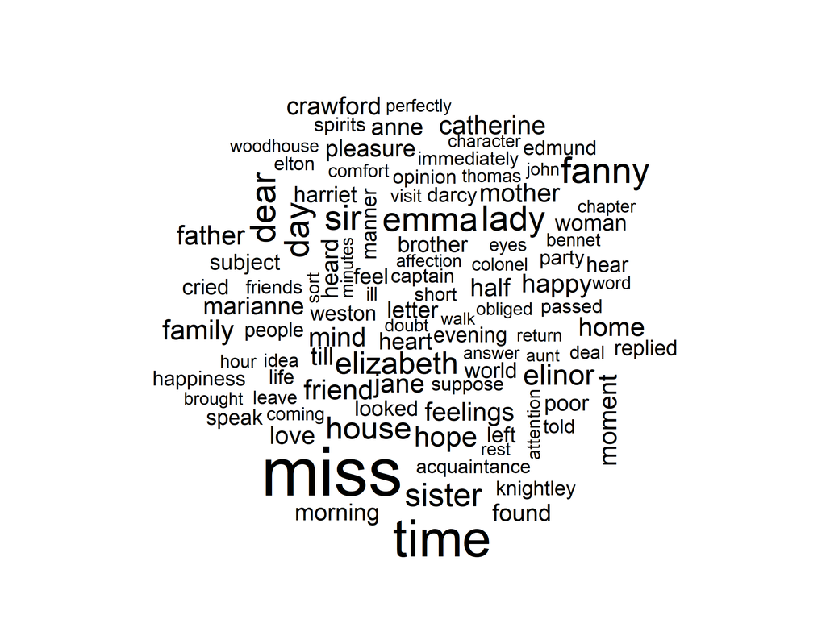

```r
tidy_books %>%
  anti_join(stop_words) %>%
  count(word) %>%
  with(wordcloud(word, n, max.words = 100))
```

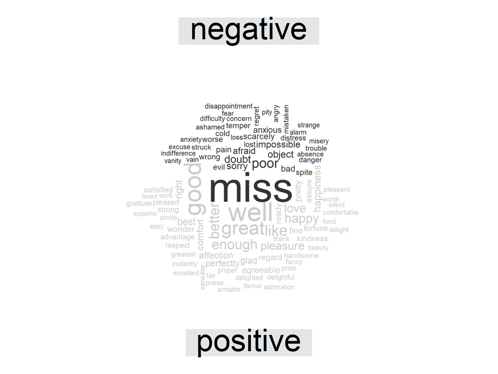

```r
tidy_books %>%
  inner_join(get_sentiments("bing")) %>%
  count(word, sentiment, sort = TRUE) %>%
  acast(word ~ sentiment, value.var = "n", fill = 0) %>%
  comparison.cloud(colors = c("gray20", "gray80"),
                   max.words = 100)
```

## 2.6 Looking at units beyond words

Splitting into sentences and chapters instead of words:

```r
p_and_p_sentences <- tibble(text = prideprejudice) %>%
  unnest_tokens(sentence, text, token = "sentences")

p_and_p_sentences$sentence[2]
```

```
[1] "by jane austen"
```

```r
austen_chapters <- austen_books() %>%
  group_by(book) %>%
  unnest_tokens(chapter, text, token = "regex",
                pattern = "Chapter|CHAPTER [\\dIVXLC]") %>%
  ungroup()

austen_chapters %>%
  group_by(book) %>%
  summarise(chapters = n())
```

| book | chapters |
| --- | --- |
| Sense & Sensibility | 51 |
| Pride & Prejudice | 62 |
| Mansfield Park | 49 |
| Emma | 56 |
| Northanger Abbey | 32 |
| Persuasion | 25 |

The most negative chapter in each novel, as a share of its words:

```r
bingnegative <- get_sentiments("bing") %>%
  filter(sentiment == "negative")

wordcounts <- tidy_books %>%
  group_by(book, chapter) %>%
  summarize(words = n())

tidy_books %>%
  semi_join(bingnegative) %>%
  group_by(book, chapter) %>%
  summarize(negativewords = n()) %>%
  left_join(wordcounts, by = c("book", "chapter")) %>%
  mutate(ratio = negativewords/words) %>%
  filter(chapter != 0) %>%
  slice_max(ratio, n = 1) %>%
  ungroup()
```

| book | chapter | negativewords | words | ratio |
| --- | --- | --- | --- | --- |
| Sense & Sensibility | 43 | 161 | 3405 | 0.0472834 |
| Pride & Prejudice | 34 | 111 | 2104 | 0.0527567 |
| Mansfield Park | 46 | 173 | 3685 | 0.0469471 |
| Emma | 15 | 151 | 3340 | 0.0452096 |
| Northanger Abbey | 21 | 149 | 2982 | 0.0499665 |
| Persuasion | 4 | 62 | 1807 | 0.0343110 |

# Part 2: Extending the Analysis

## New corpus: two 1920s novels

|  | *The Great Gatsby* | *The Sun Also Rises* |
| --- | --- | --- |
| Author | F. Scott Fitzgerald | Ernest Hemingway |
| Published | 1925 | 1926 |
| Project Gutenberg ID | 64317 | 67138 |
| US public domain since | 2021 | 2022 |

Downloaded with `gutenbergr`. The first render saves a CSV copy, and later renders read from it, so the report doesn’t depend on the Gutenberg mirror.

```r
book_titles <- c(`64317` = "The Great Gatsby", `67138` = "The Sun Also Rises")
books_file <- "gatsby_sun_also_rises.csv"

if (file.exists(books_file)) {
  raw_books <- read_csv(books_file, col_types = "ic", na = character())
} else {
  raw_books <- gutenberg_download(c(64317, 67138))
  write_csv(raw_books, books_file, na = "")
}
```

### Cleaning

The book’s Austen chapter pattern doesn’t fit either book, so each gets its own rule:

|  | *The Great Gatsby* | *The Sun Also Rises* |
| --- | --- | --- |
| Story starts at | The second “I” (the first is in the table of contents) | The first “CHAPTER” |
| Chapter headings | A Roman numeral alone on a line | “CHAPTER” on one line, the number on the next |
| Also dropped | Title page, dedication, epigraph | Front matter, “BOOK II/III” titles, transcriber’s note after “THE END” |

Curly quotes and apostrophes are straightened so “don’t” matches the lexicons’ spelling.

```r
new_books <- raw_books %>%
  mutate(
    book = factor(book_titles[as.character(gutenberg_id)], levels = book_titles),
    text = str_replace_all(text, "[‘’]", "'"),
    text = str_replace_all(text, "[“”]", '"'),
    trimmed = str_trim(text)
  ) %>%
  group_by(book) %>%
  mutate(
    start = if_else(book == "The Great Gatsby",
                    which(trimmed == "I")[2],
                    which(trimmed == "CHAPTER")[1]),
    end = coalesce(which(trimmed == "THE END")[1], n() + 1L)
  ) %>%
  filter(row_number() >= start, row_number() < end) %>%
  mutate(
    heading = if_else(book == "The Great Gatsby",
                      str_detect(trimmed, "^[IVX]+$"),
                      trimmed == "CHAPTER"),
    chapter = cumsum(heading)
  ) %>%
  filter(!heading,
         !str_detect(trimmed, "^BOOK [IVX]+$"),
         !str_detect(trimmed, "^\\d+$")) %>%
  mutate(linenumber = row_number()) %>%
  ungroup() %>%
  select(book, linenumber, chapter, text)

tidy_new <- new_books %>%
  unnest_tokens(word, text)
```

Check against the books (9 chapters in *Gatsby*, 19 in *The Sun Also Rises*):

```r
new_books %>%
  group_by(Book = book) %>%
  summarise(Chapters = n_distinct(chapter),
            `First line of the story` = first(text[str_trim(text) != ""]))
```

| Book | Chapters | First line of the story |
| --- | --- | --- |
| The Great Gatsby | 9 | In my younger and more vulnerable years my father gave me some advice |
| The Sun Also Rises | 19 | Robert Cohn was once middleweight boxing champion of Princeton. Do not |

### Section size

The book scores 80-line sections and notes the right size depends on the text. These books have shorter lines than Austen’s:

```r
section_size <- bind_rows(
  tibble(book = "Jane Austen (all 6 novels)",
         words = nrow(tidy_books),
         lines = nrow(austen_books())),
  tidy_new %>% count(book, name = "words") %>%
    left_join(new_books %>% count(book, name = "lines"), by = "book") %>%
    mutate(book = as.character(book))
) %>%
  mutate(words_per_line = words / lines)

section_size %>%
  transmute(Book = book,
            Words = format(words, big.mark = ","),
            Lines = format(lines, big.mark = ","),
            `Words per line` = round(words_per_line, 1))
```

| Book | Words | Lines | Words per line |
| --- | --- | --- | --- |
| Jane Austen (all 6 novels) | 725,055 | 73,422 | 9.9 |
| The Great Gatsby | 48,636 | 6,357 | 7.7 |
| The Sun Also Rises | 68,305 | 10,110 | 6.8 |

```r
austen_wpl <- section_size %>% filter(!book %in% book_titles) %>% pull(words_per_line)
new_wpl <- section_size %>% filter(book %in% book_titles) %>% pull(words_per_line)

new_section_size <- round(80 * austen_wpl / mean(new_wpl), -1)
```

**Takeaway:** the new books use **110-line sections**, so each section holds about as much text as the book’s 80-line Austen sections. *Pride & Prejudice* stays at 80.

## Sentiment through each novel

The Bing net-sentiment arc from Section 2.2, for the new books:

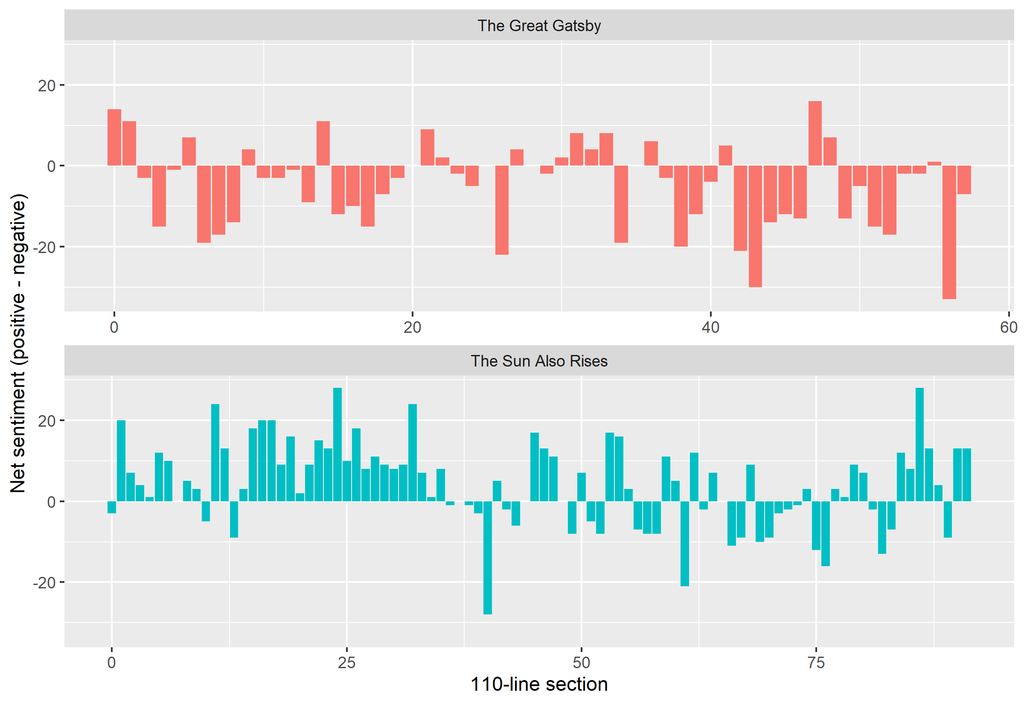

```r
new_sentiment <- tidy_new %>%
  inner_join(get_sentiments("bing"), by = "word") %>%
  count(book, index = linenumber %/% new_section_size, sentiment) %>%
  pivot_wider(names_from = sentiment, values_from = n, values_fill = 0) %>%
  mutate(sentiment = positive - negative)

ggplot(new_sentiment, aes(index, sentiment, fill = book)) +
  geom_col(show.legend = FALSE) +
  facet_wrap(~book, ncol = 1, scales = "free_x") +
  labs(x = paste0(new_section_size, "-line section"), y = "Net sentiment (positive - negative)")
```

| Sections that score negative |  |
| --- | --- |
| Austen (6 novels) | 11% to 26% |
| *The Great Gatsby* | 64% |
| *The Sun Also Rises* | 33% |

**Takeaway:** Austen’s arcs stay mostly above zero. *Gatsby* spends most of its length below.

## Overall tone compared with Austen

All eight books, scored per 1,000 words so long and short books compare fairly:

```r
all_tidy <- bind_rows(
  tidy_books %>% mutate(book = as.character(book), author = "Austen"),
  tidy_new %>% mutate(book = as.character(book),
                      author = if_else(book == "The Great Gatsby", "Fitzgerald", "Hemingway"))
)

bing_rates <- all_tidy %>%
  left_join(get_sentiments("bing"), by = "word") %>%
  group_by(author, book) %>%
  summarise(words = n(),
            matched = sum(!is.na(sentiment)),
            positive = sum(sentiment == "positive", na.rm = TRUE),
            negative = sum(sentiment == "negative", na.rm = TRUE),
            .groups = "drop")

nrc_rates <- all_tidy %>%
  inner_join(get_sentiments("nrc") %>% filter(sentiment %in% c("positive", "negative")),
             by = "word") %>%
  group_by(book) %>%
  summarise(nrc_positive_share = mean(sentiment == "positive"))

tone <- bing_rates %>%
  left_join(nrc_rates, by = "book") %>%
  mutate(matched_per_1k = matched / words * 1000,
         net_per_1k = (positive - negative) / words * 1000,
         bing_positive_share = positive / matched)

tone %>%
  arrange(desc(net_per_1k)) %>%
  transmute(Author = author,
            Book = book,
            `Net sentiment per 1,000` = round(net_per_1k, 1),
            `Sentiment words per 1,000` = round(matched_per_1k, 1),
            `Bing: % positive` = scales::percent(bing_positive_share, accuracy = 1),
            `NRC: % positive` = scales::percent(nrc_positive_share, accuracy = 1))
```

| Author | Book | Net sentiment per 1,000 | Sentiment words per 1,000 | Bing: % positive | NRC: % positive |
| --- | --- | --- | --- | --- | --- |
| Austen | Persuasion | 15.2 | 67.8 | 61% | 70% |
| Austen | Emma | 14.6 | 74.3 | 60% | 68% |
| Austen | Mansfield Park | 12.0 | 72.1 | 58% | 66% |
| Austen | Pride & Prejudice | 11.5 | 71.2 | 58% | 67% |
| Austen | Sense & Sensibility | 10.5 | 71.7 | 57% | 65% |
| Austen | Northanger Abbey | 9.3 | 74.1 | 56% | 65% |
| Hemingway | The Sun Also Rises | 5.6 | 50.8 | 56% | 60% |
| Fitzgerald | The Great Gatsby | -5.9 | 57.6 | 45% | 55% |

- **Net sentiment:** Austen 9.3 to 15.2 · *Gatsby* -5.9 · *The Sun Also Rises* 5.6
- **Sentiment words per 1,000:** Austen 68 to 74 · *Gatsby* 58 · *The Sun Also Rises* 51
- **NRC runs higher than Bing** (the book’s finding): true for all eight books

**Takeaway:** the new books have less sentiment vocabulary for the lexicons to work with, and *Gatsby* is the only negative book.

## Adding a fourth method: `sentimentr`

The Chapter 2 lexicons score one word at a time, so “not good” counts as positive. `sentimentr` (Rinker), which the book mentions in Section 2.6, scores whole sentences and adjusts for nearby words:

| Word type | Example | Effect |
| --- | --- | --- |
| Negator | “not” | Flips the score |
| Amplifier | “very” | Strengthens it |
| De-amplifier | “hardly” | Weakens it |

All four methods are scored on the same sections. For `sentimentr`, each section’s sentences are scored and summed.

```r
score_sections <- function(lines, size = 80) {
  lines <- lines %>% mutate(index = linenumber %/% size)
  words <- lines %>% unnest_tokens(word, text)

  afinn_scores <- words %>%
    inner_join(get_sentiments("afinn"), by = "word") %>%
    group_by(book, index) %>%
    summarise(sentiment = sum(value), .groups = "drop") %>%
    mutate(method = "AFINN")

  bing_nrc_scores <- bind_rows(
    words %>%
      inner_join(get_sentiments("bing"), by = "word") %>%
      mutate(method = "Bing et al."),
    words %>%
      inner_join(get_sentiments("nrc") %>%
                   filter(sentiment %in% c("positive", "negative")),
                 by = "word") %>%
      mutate(method = "NRC")
  ) %>%
    count(book, method, index, sentiment) %>%
    pivot_wider(names_from = sentiment, values_from = n, values_fill = 0) %>%
    mutate(sentiment = positive - negative) %>%
    select(book, index, method, sentiment)

  sentimentr_scores <- lines %>%
    group_by(book, index) %>%
    summarise(text = str_squish(paste(text, collapse = " ")), .groups = "drop") %>%
    get_sentences() %>%
    sentiment() %>%
    as_tibble() %>%
    group_by(book, index) %>%
    summarise(sentiment = sum(sentiment, na.rm = TRUE), .groups = "drop") %>%
    mutate(method = "sentimentr")

  bind_rows(afinn_scores, bing_nrc_scores, sentimentr_scores) %>%
    mutate(method = factor(method,
                           levels = c("AFINN", "Bing et al.", "NRC", "sentimentr")))
}

pp_lines <- austen_books() %>%
  filter(book == "Pride & Prejudice") %>%
  mutate(linenumber = row_number(),
         chapter = cumsum(str_detect(text, regex("^chapter [\\divxlc]", ignore_case = TRUE))),
         book = "Pride & Prejudice")

section_scores <- bind_rows(
  score_sections(pp_lines),
  score_sections(new_books %>% mutate(book = as.character(book)), size = new_section_size)
) %>%
  mutate(book = factor(book, levels = c("Pride & Prejudice", book_titles)))
```

Each panel has its own scale. Compare the shape of the bars, not their height:

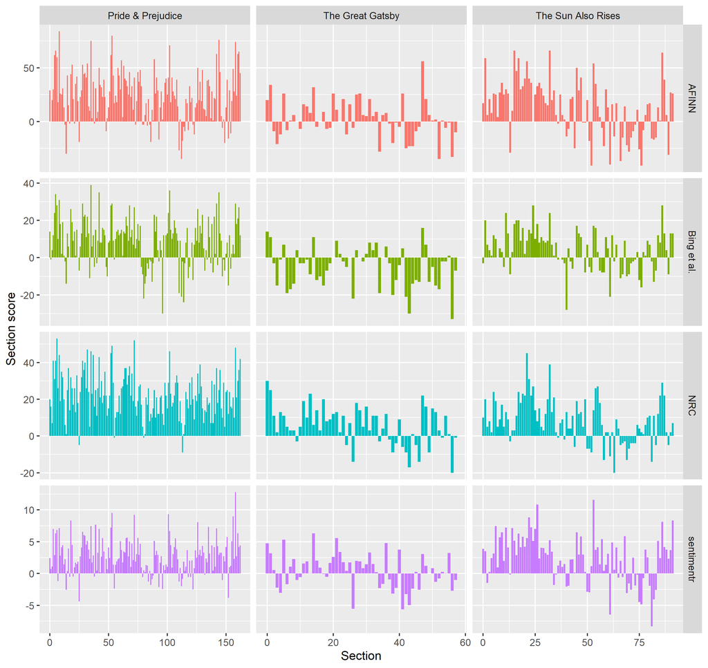

```r
ggplot(section_scores, aes(index, sentiment, fill = method)) +
  geom_col(show.legend = FALSE) +
  facet_grid(method ~ book, scales = "free") +
  labs(x = "Section", y = "Section score")
```

### Do the methods agree?

The book found the lexicons share the **same ups and downs**. Correlation measures that: 1 = they move together, 0 = no relationship.

```r
agreement <- section_scores %>%
  pivot_wider(names_from = method, values_from = sentiment, values_fill = 0) %>%
  group_by(Book = book) %>%
  summarise(
    `AFINN vs Bing` = cor(AFINN, `Bing et al.`),
    `AFINN vs NRC` = cor(AFINN, NRC),
    `Bing vs NRC` = cor(`Bing et al.`, NRC),
    `sentimentr vs Bing` = cor(sentimentr, `Bing et al.`),
    `sentimentr vs AFINN` = cor(sentimentr, AFINN)
  )

agreement %>% mutate(across(-Book, ~ round(.x, 2)))
```

| Book | AFINN vs Bing | AFINN vs NRC | Bing vs NRC | sentimentr vs Bing | sentimentr vs AFINN |
| --- | --- | --- | --- | --- | --- |
| Pride & Prejudice | 0.81 | 0.72 | 0.71 | 0.76 | 0.72 |
| The Great Gatsby | 0.77 | 0.60 | 0.63 | 0.68 | 0.59 |
| The Sun Also Rises | 0.80 | 0.70 | 0.56 | 0.68 | 0.69 |

**Takeaway:** average agreement between the three word lexicons is 0.75 on *Pride & Prejudice*, 0.67 on *Gatsby* and 0.69 on *The Sun Also Rises*. They still move together on the new books, just less closely.

### Where word-level and sentence-level scoring disagree

Every sentence is scored twice, by Bing and by `sentimentr`, to see how often they point in opposite directions:

```r
score_sentences <- function(lines) {
  sentences <- lines %>%
    group_by(book, chapter) %>%
    summarise(text = str_squish(paste(text, collapse = " ")), .groups = "drop") %>%
    get_sentences() %>%
    sentiment() %>%
    as_tibble() %>%
    transmute(book, chapter, sentence_id = row_number(), text = as.character(text),
              word_count, sentimentr = sentiment)

  bing_by_sentence <- sentences %>%
    select(sentence_id, text) %>%
    unnest_tokens(word, text) %>%
    inner_join(get_sentiments("bing"), by = "word") %>%
    group_by(sentence_id) %>%
    summarise(bing = sum(sentiment == "positive") - sum(sentiment == "negative"))

  sentences %>%
    left_join(bing_by_sentence, by = "sentence_id") %>%
    mutate(bing = coalesce(bing, 0L))
}

sentence_scores <- bind_rows(
  score_sentences(pp_lines),
  score_sentences(new_books %>% mutate(book = as.character(book)))
) %>%
  mutate(book = factor(book, levels = c("Pride & Prejudice", book_titles)))

disagreement <- sentence_scores %>%
  filter(bing != 0, sentimentr != 0) %>%
  group_by(book) %>%
  summarise(scored = n(), opposite = mean(sign(bing) != sign(sentimentr)))

disagreement %>%
  transmute(Book = book,
            `Sentences both methods scored` = format(scored, big.mark = ","),
            `Scored in opposite directions` = scales::percent(opposite, accuracy = 0.1))
```

| Book | Sentences both methods scored | Scored in opposite directions |
| --- | --- | --- |
| Pride & Prejudice | 3,346 | 20.6% |
| The Great Gatsby | 1,405 | 14.1% |
| The Sun Also Rises | 2,428 | 17.5% |

Examples with a negating word. **Bing** = positive minus negative words. **sentimentr** = the sentence score. Above 0 is positive for both.

```r
negators <- "\\b(not|no|never|nothing|nobody|don't|didn't|isn't|wasn't|couldn't|wouldn't|can't)\\b"

examples <- sentence_scores %>%
  filter(book != "Pride & Prejudice",
         bing != 0, sign(bing) != sign(sentimentr),
         between(word_count, 5, 22),
         str_detect(str_to_lower(text), negators)) %>%
  group_by(book) %>%
  slice_max(abs(sentimentr), n = 4, with_ties = FALSE) %>%
  ungroup()

for (b in book_titles) {
  cat("\n\n**", b, "**\n\n", sep = "")
  examples %>%
    filter(book == b) %>%
    transmute(Sentence = text, Bing = bing, sentimentr = round(sentimentr, 2)) %>%
    knitr::kable() %>%
    print()
}
```

**The Great Gatsby**

| Sentence | Bing | sentimentr |
| --- | --- | --- |
| “I told her she might fool me but she couldn’t fool God. | -2 | 0.49 |
| He knew that Daisy was extraordinary, but he didn’t realize just how extraordinary a “nice” girl could be. | 3 | -0.49 |
| “I just slip it on sometimes when I don’t care what I look like.” | 1 | -0.47 |
| But he didn’t despise himself and it didn’t turn out as he had imagined. | -1 | 0.45 |

**The Sun Also Rises**

| Sentence | Bing | sentimentr |
| --- | --- | --- |
| “But he’s not aficionado like you.” | 1 | -1.19 |
| “But he’s not aficionado like you are.” | 1 | -1.11 |
| This is all awfully amusing, but it’s not too pleasant. | 1 | -0.87 |
| “Don’t be a damned fool.” | -2 | 0.78 |

| `sentimentr` gets it right | `sentimentr` gets it wrong |
| --- | --- |
| “it’s not too pleasant”: reads the “not”, scores negative | “Don’t be a damned fool”: the “don’t” flips the insult, scores positive |

**Takeaway:** the two methods disagree on 14% to 18% of sentences in the new books (21% in *Pride & Prejudice*), and neither is consistently right.

## Words that get misread

The Section 2.4 chart for each new book:

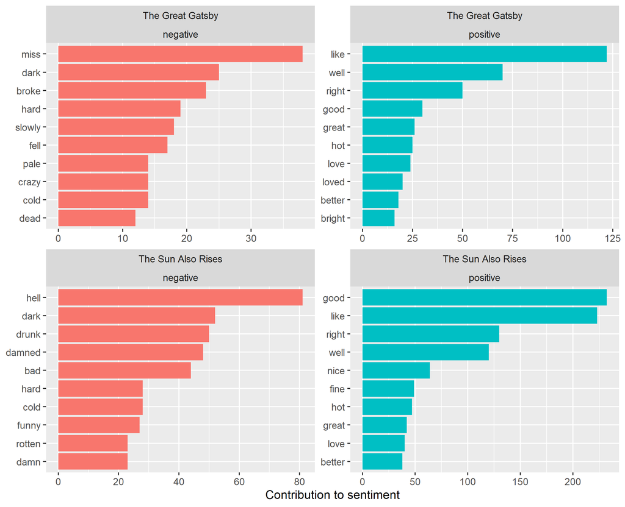

```r
new_word_counts <- tidy_new %>%
  inner_join(get_sentiments("bing"), by = "word") %>%
  count(book, word, sentiment, sort = TRUE)

new_word_counts %>%
  group_by(book, sentiment) %>%
  slice_max(n, n = 10, with_ties = FALSE) %>%
  ungroup() %>%
  mutate(word = reorder_within(word, n, list(book, sentiment))) %>%
  ggplot(aes(n, word, fill = sentiment)) +
  geom_col(show.legend = FALSE) +
  facet_wrap(book ~ sentiment, scales = "free") +
  scale_y_reordered() +
  labs(x = "Contribution to sentiment", y = NULL)
```

### *Gatsby*: “miss” again

- Top negative word: **38 uses**
- **31** of them are “Miss” + a name (mostly Miss Baker)

Applying the book’s custom stop word fix from Section 2.4:

```r
net_per_1k <- function(tidy) {
  tidy %>%
    inner_join(get_sentiments("bing"), by = "word") %>%
    group_by(book) %>%
    summarise(net = sum(sentiment == "positive") - sum(sentiment == "negative")) %>%
    left_join(tidy_new %>% count(book, name = "words"), by = "book") %>%
    mutate(net_per_1k = net / words * 1000)
}

miss_fix <- bind_rows(
  net_per_1k(tidy_new) %>% mutate(version = "As scored"),
  net_per_1k(tidy_new %>% anti_join(custom_stop_words %>% filter(lexicon == "custom"), by = "word")) %>%
    mutate(version = "Without \"miss\"")
)

miss_fix %>%
  select(Book = book, version, net_per_1k) %>%
  mutate(net_per_1k = round(net_per_1k, 1)) %>%
  pivot_wider(names_from = version, values_from = net_per_1k)
```

| Book | As scored | Without “miss” |
| --- | --- | --- |
| The Great Gatsby | -5.9 | -5.1 |
| The Sun Also Rises | 5.6 | 5.6 |

**Takeaway:** *Gatsby* is still negative without “miss”, so the misread word isn’t what makes it negative.

### *The Sun Also Rises*: “damned”

The characters use “damned” and “damn” to mean “very” (“damned good”), but Bing scores them negative. The word right after each one:

```r
damned_bigrams <- new_books %>%
  filter(book == "The Sun Also Rises") %>%
  unnest_tokens(bigram, text, token = "ngrams", n = 2) %>%
  filter(!is.na(bigram)) %>%
  separate(bigram, c("word1", "word2"), sep = " ") %>%
  filter(word1 %in% c("damned", "damn")) %>%
  inner_join(get_sentiments("bing"), by = c("word2" = "word"))

damned_bigrams %>%
  count(`Next word is` = sentiment, name = "Times") %>%
  mutate(Share = scales::percent(Times / sum(Times), accuracy = 1))
```

| Next word is | Times | Share |
| --- | --- | --- |
| negative | 18 | 35% |
| positive | 34 | 65% |

```r
damned_bigrams %>%
  unite(Phrase, word1, word2, sep = " ") %>%
  count(Phrase, sort = TRUE) %>%
  head(8)
```

| Phrase | n |
| --- | --- |
| damned good | 8 |
| damn good | 4 |
| damned nice | 4 |
| damned well | 4 |
| damn nice | 2 |
| damned fine | 2 |
| damned hard | 2 |
| damn bad | 1 |

**Takeaway:** the next word is positive **65%** of the time, so “damned good” cancels to zero instead of counting as praise.

## Wordclouds by sentiment

One cloud per book instead of the book’s split gray halves:

- **Size** = how often the word appears
- **Color** = AFINN score: red is negative, green is positive, darker is stronger
- Stop words like “no” and “like” removed

```r
cloud_colors <- c("#7f1d1d", "#991b1b", "#b91c1c", "#d62f2f", "#e05252",   # -5 to -1
                  "#888888",                                                # 0
                  "#3f9e5f", "#2f8a4f", "#237a42", "#166534", "#0f4d27")   # +1 to +5

sentiment_cloud <- function(tidy) {
  words <- tidy %>%
    anti_join(stop_words, by = "word") %>%
    inner_join(get_sentiments("afinn"), by = "word") %>%
    count(word, value, sort = TRUE) %>%
    head(100)
  set.seed(607)
  wordcloud(words$word, words$n,
            colors = cloud_colors[words$value + 6], ordered.colors = TRUE,
            random.order = FALSE, scale = c(4, 0.6))
}
```

**Jane Austen**

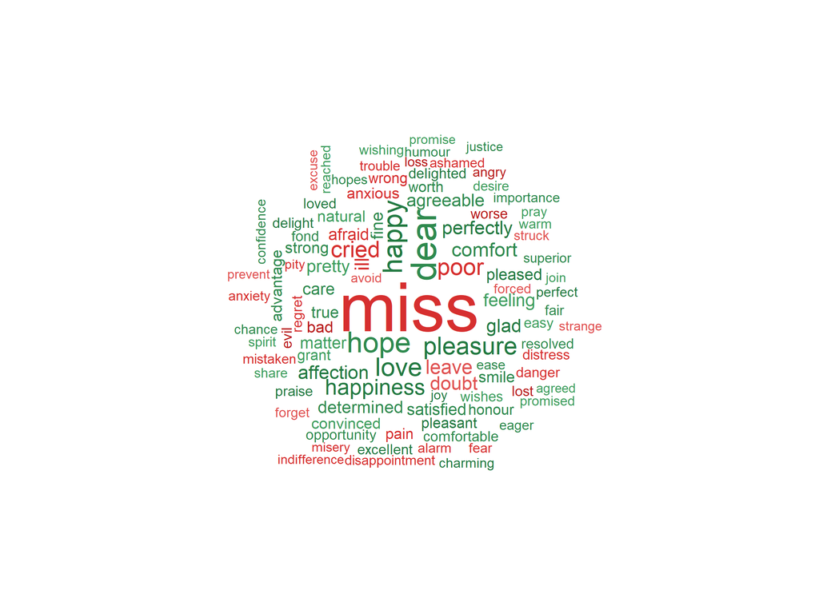

```r
sentiment_cloud(tidy_books)
```

**The Great Gatsby**

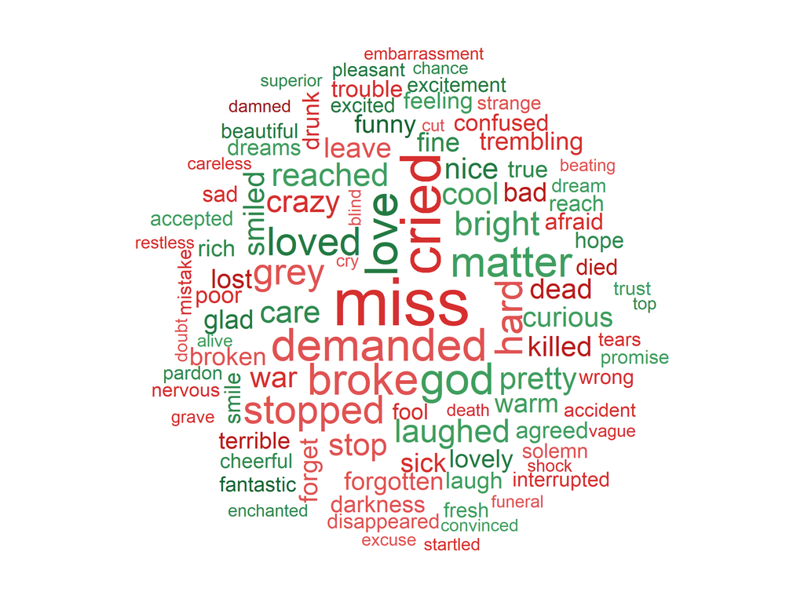

```r
sentiment_cloud(tidy_new %>% filter(book == "The Great Gatsby"))
```

**The Sun Also Rises**

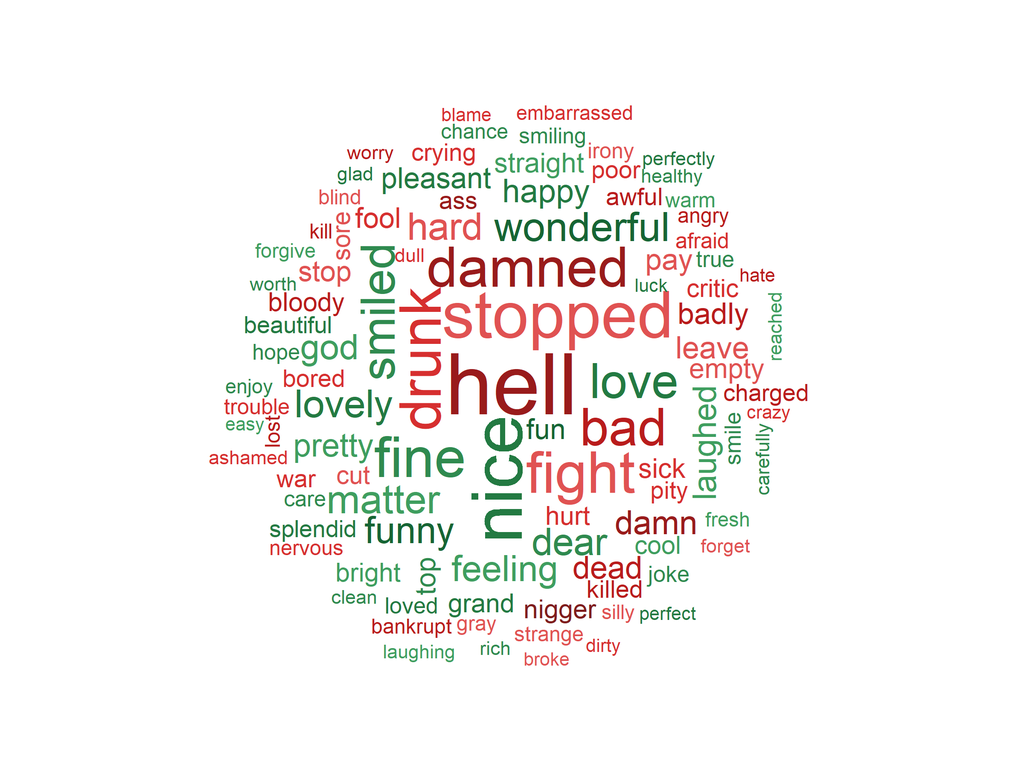

```r
sentiment_cloud(tidy_new %>% filter(book == "The Sun Also Rises"))
```

## Most negative chapter in each book

The Section 2.6 test: the chapter with the highest share of negative words.

```r
new_wordcounts <- tidy_new %>%
  count(book, chapter, name = "words")

new_negative <- tidy_new %>%
  semi_join(bingnegative, by = "word") %>%
  count(book, chapter, name = "negativewords") %>%
  left_join(new_wordcounts, by = c("book", "chapter")) %>%
  mutate(ratio = negativewords / words) %>%
  group_by(book) %>%
  slice_max(ratio, n = 1) %>%
  ungroup()

new_negative %>%
  transmute(Book = book, Chapter = chapter,
            `Negative words` = negativewords, Words = words,
            `Share negative` = scales::percent(ratio, accuracy = 0.1))
```

| Book | Chapter | Negative words | Words | Share negative |
| --- | --- | --- | --- | --- |
| The Great Gatsby | 7 | 320 | 8839 | 3.6% |
| The Sun Also Rises | 12 | 128 | 3981 | 3.2% |

The top negative words in *The Sun Also Rises*’s pick:

```r
tidy_new %>%
  filter(book == "The Sun Also Rises",
         chapter == new_negative$chapter[new_negative$book == "The Sun Also Rises"]) %>%
  semi_join(bingnegative, by = "word") %>%
  count(word, sort = TRUE) %>%
  head(10)
```

| word | n |
| --- | --- |
| hell | 10 |
| irony | 10 |
| pity | 9 |
| cold | 8 |
| falls | 5 |
| ironical | 4 |
| jam | 4 |
| steep | 4 |
| bait | 3 |
| bum | 3 |

| Book | Chapter | What happens | Right call? |
| --- | --- | --- | --- |
| *The Great Gatsby* | 7 | The Plaza Hotel confrontation and Myrtle’s death | Yes |
| *The Sun Also Rises* | 12 | The fishing trip in the mountains, one of the happiest stretches. Top “negative” words come from Bill’s “Irony and Pity” joke, plus “cold” and “falls” (waterfalls) | No |

## Sentiment around each character

Names aren’t in any lexicon, so this scores the **sentences that mention each character** with `sentimentr`, then compares the share that read positive vs negative.

| This measures | This doesn’t measure |
| --- | --- |
| The mood of the scenes a character appears in | Whether the character is good or bad |
| How the narrator describes them | Sentences that use “he” or “she” instead of the name |
| How that mood changes chapter by chapter | The narrators, Nick and Jake, who are mostly “I” |

```r
characters <- tribble(
  ~book,                ~character,        ~pattern,
  "The Great Gatsby",   "Gatsby",          "\\bgatsby",
  "The Great Gatsby",   "Daisy",           "\\bdaisy",
  "The Great Gatsby",   "Tom",             "\\btom\\b",
  "The Great Gatsby",   "Jordan",          "\\bjordan\\b|\\bmiss baker\\b",
  "The Great Gatsby",   "Myrtle",          "\\bmyrtle\\b|\\bmrs\\. wilson\\b",
  "The Great Gatsby",   "George Wilson",   "(?<!mrs\\. )\\bwilson\\b",
  "The Great Gatsby",   "Nick (narrator)", "\\bnick\\b|\\bcarraway\\b",
  "The Sun Also Rises", "Brett",           "\\bbrett\\b",
  "The Sun Also Rises", "Cohn",            "\\bcohn\\b|\\brobert\\b",
  "The Sun Also Rises", "Bill",            "\\bbill\\b",
  "The Sun Also Rises", "Mike",            "\\bmike\\b|\\bmichael\\b",
  "The Sun Also Rises", "Romero",          "\\bromero\\b",
  "The Sun Also Rises", "Montoya",         "\\bmontoya\\b",
  "The Sun Also Rises", "Jake (narrator)", "\\bjake\\b|\\bbarnes\\b"
)

new_sentences <- sentence_scores %>%
  filter(book != "Pride & Prejudice") %>%
  mutate(book = as.character(book), lower = str_to_lower(text))

character_sentences <- characters %>%
  inner_join(new_sentences, by = "book", relationship = "many-to-many") %>%
  filter(str_detect(lower, pattern))

character_summary <- character_sentences %>%
  group_by(book, character) %>%
  summarise(mentions = n(),
            positive = mean(sentimentr > 0),
            negative = mean(sentimentr < 0),
            .groups = "drop") %>%
  mutate(net = positive - negative)

book_baseline <- new_sentences %>%
  group_by(book) %>%
  summarise(net = mean(sentimentr > 0) - mean(sentimentr < 0))
```

The bar is the share of a character’s sentences that read positive minus the share that read negative. The dashed line is the whole book’s average.

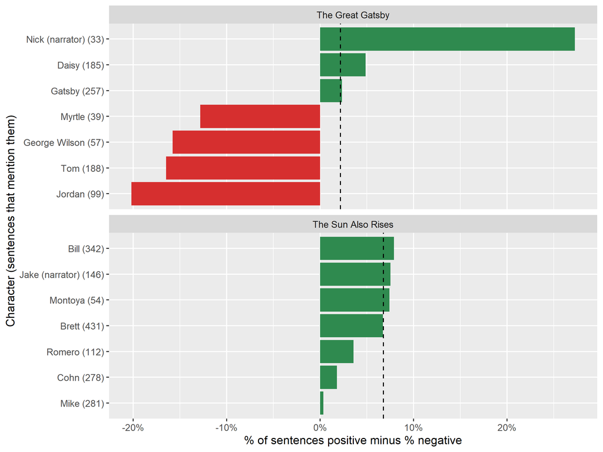

```r
character_summary %>%
  mutate(label = paste0(character, " (", mentions, ")"),
         label = reorder_within(label, net, book)) %>%
  ggplot(aes(net, label, fill = net > 0)) +
  geom_col(show.legend = FALSE) +
  geom_vline(data = book_baseline, aes(xintercept = net), linetype = "dashed") +
  facet_wrap(~book, ncol = 1, scales = "free_y") +
  scale_y_reordered() +
  scale_fill_manual(values = c(`TRUE` = "#2f8a4f", `FALSE` = "#d62f2f")) +
  scale_x_continuous(labels = scales::label_percent()) +
  labs(x = "% of sentences positive minus % negative",
       y = "Character (sentences that mention them)")
```

```r
character_summary %>%
  arrange(book, net) %>%
  transmute(Book = book, Character = character, Mentions = mentions,
            `Read positive` = scales::percent(positive, accuracy = 1),
            `Read negative` = scales::percent(negative, accuracy = 1))
```

| Book | Character | Mentions | Read positive | Read negative |
| --- | --- | --- | --- | --- |
| The Great Gatsby | Jordan | 99 | 31% | 52% |
| The Great Gatsby | Tom | 188 | 30% | 46% |
| The Great Gatsby | George Wilson | 57 | 25% | 40% |
| The Great Gatsby | Myrtle | 39 | 28% | 41% |
| The Great Gatsby | Gatsby | 257 | 34% | 32% |
| The Great Gatsby | Daisy | 185 | 40% | 35% |
| The Great Gatsby | Nick (narrator) | 33 | 39% | 12% |
| The Sun Also Rises | Mike | 281 | 23% | 22% |
| The Sun Also Rises | Cohn | 278 | 23% | 22% |
| The Sun Also Rises | Romero | 112 | 34% | 30% |
| The Sun Also Rises | Brett | 431 | 26% | 19% |
| The Sun Also Rises | Montoya | 54 | 30% | 22% |
| The Sun Also Rises | Jake (narrator) | 146 | 27% | 19% |
| The Sun Also Rises | Bill | 342 | 24% | 16% |

How the mood around the central characters changes chapter by chapter (chapters with at least 5 mentions):

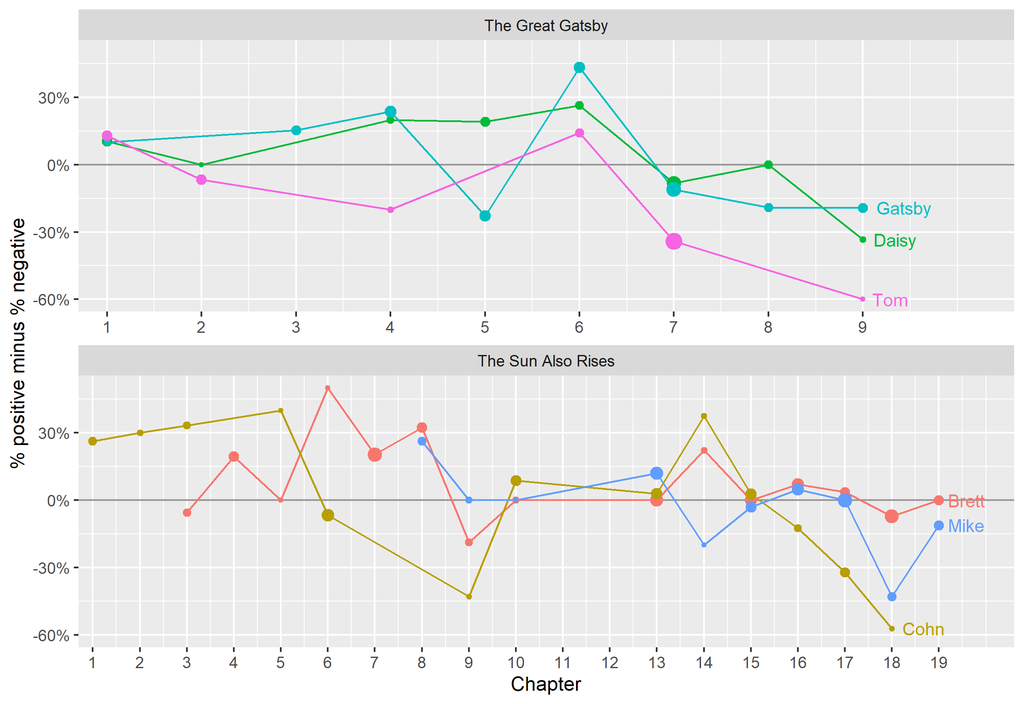

```r
central <- c("Gatsby", "Daisy", "Tom", "Brett", "Cohn", "Mike")

by_chapter <- character_sentences %>%
  filter(character %in% central) %>%
  group_by(book, character, chapter) %>%
  summarise(mentions = n(),
            net = mean(sentimentr > 0) - mean(sentimentr < 0),
            .groups = "drop") %>%
  filter(mentions >= 5)

line_labels <- by_chapter %>%
  group_by(book, character) %>%
  slice_max(chapter, n = 1)

ggplot(by_chapter, aes(chapter, net, color = character)) +
  geom_hline(yintercept = 0, color = "grey60") +
  geom_line() +
  geom_point(aes(size = mentions)) +
  geom_text(data = line_labels, aes(label = character),
            hjust = -0.25, size = 3.5, show.legend = FALSE) +
  facet_wrap(~book, ncol = 1, scales = "free_x") +
  scale_x_continuous(breaks = function(lims) seq(1, floor(lims[2] - 1.5), by = 1),
                     expand = expansion(add = c(0.3, 1.6))) +
  scale_y_continuous(labels = scales::label_percent()) +
  scale_size_area(max_size = 4, guide = "none") +
  labs(x = "Chapter", y = "% positive minus % negative") +
  theme(legend.position = "none")
```

- *Gatsby*: the scenes around Jordan, Tom, George Wilson, and Myrtle lean negative. Of the sentences that mention Tom, 46% read negative and 30% positive.
- **After the Plaza:** from chapter 7 on, Gatsby, Daisy and Tom all fall to zero or below.
- *The Sun Also Rises*: every character falls between 0% and 8%. The lowest is Mike.
- **Cohn after the fight:** from chapter 17 on, his sentences score -38%, compared with 8% before.

**Takeaway:** *Gatsby*’s negativity clusters around particular characters. *The Sun Also Rises* spreads its tone evenly across the whole group.

# *Gatsby* vs *The Sun Also Rises*

The book’s `comparison.cloud()`, comparing the two books instead of positive and negative words. **Color = which book** (blue *Gatsby*, purple *The Sun Also Rises*), not sentiment. Bigger = used much more in that book.

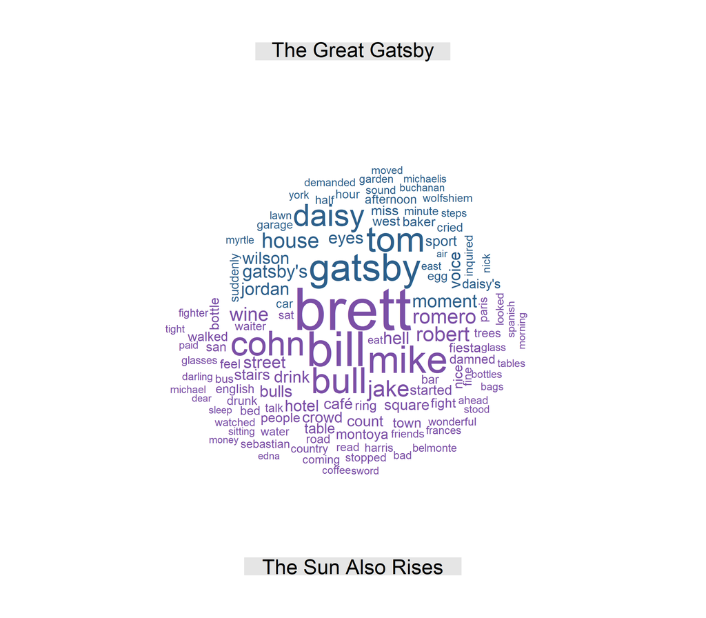

```r
set.seed(607)
tidy_new %>%
  anti_join(stop_words, by = "word") %>%
  count(word, book) %>%
  acast(word ~ book, value.var = "n", fill = 0) %>%
  comparison.cloud(colors = c("#2c5f8a", "#7b4fa6"),
                   max.words = 120, title.size = 1.4)
```

|  | *The Great Gatsby* | *The Sun Also Rises* |
| --- | --- | --- |
| Net sentiment per 1,000 words | -5.9 | 5.6 |
| Sections that score negative | 64% | 33% |
| Sentiment words per 1,000 | 58 | 51 |
| Lexicon agreement | 0.67 | 0.69 |
| Misread word | “miss” (a title) | “damned” (emphasis) |
| Most negative chapter | 7, fits the plot | 12, a misread joke |
| Characters | Negativity clusters around a few | Everyone near the book’s average |

**Takeaway:** same era, very different results. The author’s style matters more than the decade.

# How the Results Differ from the Original

| Question from my approach | Austen (Chapter 2) | *Gatsby* and *The Sun Also Rises* |
| --- | --- | --- |
| Overall tone | Positive: 9.3 to 15.2 per 1,000 words | *Gatsby* -5.9, *Sun* 5.6 |
| Do the lexicons agree? | Yes: 0.75 | Less: 0.67 and 0.69 |
| Does sentence-level scoring change things? | Disagrees with Bing on 21% of sentences | 14% to 18%, and not clearly better |
| The “miss” of the corpus | “miss” | “miss” (*Gatsby*), “damned” (*Sun*) |
| Darkest chapter | Matches the plot in all six novels | Right for *Gatsby*, wrong for *Sun* |

**Bottom line:** the Chapter 2 method holds up on a book with dark events (*Gatsby*), but struggles with Hemingway’s sparse, joking dialogue. The biggest errors come from context (titles, swearing for emphasis, a running joke), which no word list can see.

# Citations

Silge, J., & Robinson, D. (2017). *Text mining with R: A tidy approach*. O’Reilly Media. https://www.tidytextmining.com/sentiment.html

Silge, J., & Robinson, D. (2017). *tidy-text-mining* [Source code for the book]. GitHub. https://github.com/dgrtwo/tidy-text-mining

Rinker, T. W. (2021). *sentimentr: Calculate text polarity sentiment* [R package]. https://github.com/trinker/sentimentr

Nielsen, F. Å. (2011). A new ANEW: Evaluation of a word list for sentiment analysis in microblogs. *Proceedings of the ESWC2011 Workshop on Making Sense of Microposts*, 93–98. (AFINN lexicon)

Hu, M., & Liu, B. (2004). Mining and summarizing customer reviews. *Proceedings of the ACM SIGKDD International Conference on Knowledge Discovery and Data Mining*, 168–177. (Bing lexicon)

Mohammad, S. M., & Turney, P. D. (2013). Crowdsourcing a word–emotion association lexicon. *Computational Intelligence, 29*(3), 436–465. (NRC lexicon)

Fitzgerald, F. S. (1925). *The great Gatsby*. Project Gutenberg. https://www.gutenberg.org/ebooks/64317

Hemingway, E. (1926). *The sun also rises*. Project Gutenberg. https://www.gutenberg.org/ebooks/67138

# AI Disclosure

Claude (Anthropic) helped write and test the code in this report, including the cleaning rules for the two books, the section-size adjustment, the four-method comparison, the sentence-level comparison and the character analysis. I chose the books, the extra lexicon, the questions in my approach and the idea to analyze the characters.

Anthropic. (2026). *Claude* [Large language model]. https://claude.ai/. Accessed November 8, 2026.